# hotel_analysis

Leshen Sui, Meiqi Chi

4/16/2018

## Introduction

Nowadays, people usually plan their trips using websites like TripAdvisor, Bookings and OnTravel. There are many hotels listed on these kinds of websites and sometimes it’s hard to make decisions because of too much advertisements and not clearly organized website structure. In this project, we have two objectives. First we want to build an interactive app that facilitates the process people search for their ideal hotel here in New York City. Second, we hope to explore the hotel data behind the scene, to answer the questions such as which factor travellers care the most about a hotel, do luxury hotels really worth the price and how should a hotel improve based on users’ reviews.

We focus on hotels in New York City because New York City is one of the most famous tourist attractions in the world and thousands of tourists come here every year. As a result, there are many hotels in New York ranged from luxury hotels to youth hostels. Also because of the large number of tourists, most of the hotels here have many reviews from travellers that allow us to analyze users’ feedback.

## Description of Data

We built a web-crawler using Google Webdriver and Python packages Selenium and Beautifulsoup to scrape the NYC hotel data from the TripAdvisor website. We typed in New York City in the TripAdvisor search bar and then scraped the information of all listed hotels returned, which is in total 602 hotels, and we collected data of each hotel in four aspects. First aspect contains 43 binary variables describing the hotel facilities, such as whether it has free-Wifi, swimming pool and free breakfast and so on. Second aspect is the basic information about the hotel such as address, website, star etc. We also calculated the longitude and latitude of each hotel using GoogleMap API. The third aspect is about reviews. The reviews of hotels can be divided into five categories, ranged from the worst one-star to the best five-star. We recorded the number of each kind of reviews for each hotel. The last aspect is the price. For each hotel, there are multiple price for different room types and service. In order to obtain comparable prices, we collected the lowest price for one room per night offered by each hotel on April 17th, 2018. We collected the data using dataframe format and saved it as a csv file for later analysis.

## Analysis of Data Quality

```r
data <- read.csv("/Users/leshensui/Downloads/hotel copy.csv", header=T, na.strings=c("","NA"))
dt = unique(data)
dim(data)
```

```
## [1] 602  60
```

```r
dim(dt)
```

```
## [1] 602  60
```

```r
leaflet(data = dt) %>% addTiles() %>%
  addMarkers(~longitude, ~latitude, popup = ~as.character(name), label = ~as.character(name))
```

[interactive chart not shown]

From the map above, we can see that most of our data points cluster in the small area of New York City. However, there are two outliers one called Signature Properties while the other is A Cozy Mountain Rest Guest House that seem to locate in the wrong area. While double checking these two hotels on the TripAdvisor webpage, we found out that the address of these two hotels were incorrect. We couldn’t find these two addresses within the boundary of NYC. So we assumed that these two hotels were misclassified by TripAdvisor and we removed these two hotels from our dataset.

```r
daf <- subset(dt, name!= "Signature Properties")
daf <- subset(daf, name!= "A Cozy Mountain Rest Guest House")
leaflet(data = daf) %>% addTiles() %>%
  addMarkers(~longitude, ~latitude, popup = ~as.character(name), label = ~as.character(name))
```

[interactive chart not shown]

Now we can see that all the locations are correct with 600 hotels in NYC. Most of the hotels locate on Manhattan and south of the island is more densely populated than the north. Next we explore the missing values in the dataset.

```r
library(extracat)
sum(complete.cases(daf))
```

```
## [1] 243
```

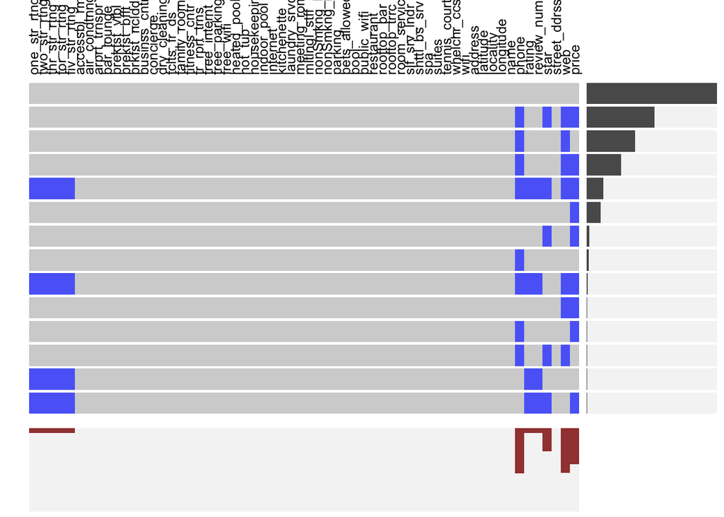

```r
visna(daf, tp = F, sort="r")
```

From the graph above, we can come up with the following observations. 1. When hotel’s reviews are missing, all five categories of reviews are missing. This means that missing values will not create bias in evaluation of users reviews of specific hotel. 2. Binary variables that describe hotels’ facilities have no missing values. However, there may be some other problems with the data collection which we will discuss later. To further analyze the missing patterns, re-draw the plot without the facilities variables.

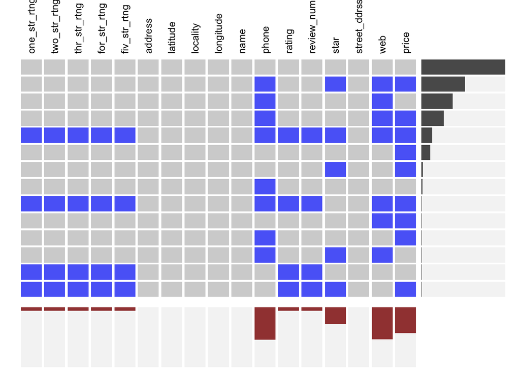

```r
visna(cbind(daf[,1:5],daf[,49:60]), tp = F, sort="r")
```

From the graph above, we can see that: 1. No hotel has missing address or missing name. 2. For those hotels that have missing values, many of them don’t have phones, websites, or prices. 3. For hotels that don’t have phones, the chance is high that they don’t have websites or prices either. 4. For those hotels that don’t have any reviews, they usually have many other missing fields too. We can assume that these hotels tend to be small ones that are not very popular so TripAdvisor doesn’t have complete information about them.

```r
leaflet(data = daf[is.na(daf$one_star_rating),]) %>% addTiles() %>%
  addMarkers(~longitude, ~latitude, popup = ~as.character(name), label = ~as.character(name))
```

[interactive chart not shown]

When we plot the hotels with missing reviews on the map, we can tell that there is no obvious spatial pattern for missing reviews. Hotels are located quite evenly in New York City.

```r
leaflet(data = daf[is.na(daf$price),]) %>% addTiles() %>%
  addMarkers(~longitude, ~latitude, popup = ~as.character(name), label = ~as.character(name))
```

[interactive chart not shown]

Now we plot the hotels with missing prices on the map. The spatial distribution is very similar to the distribution of the whole population.

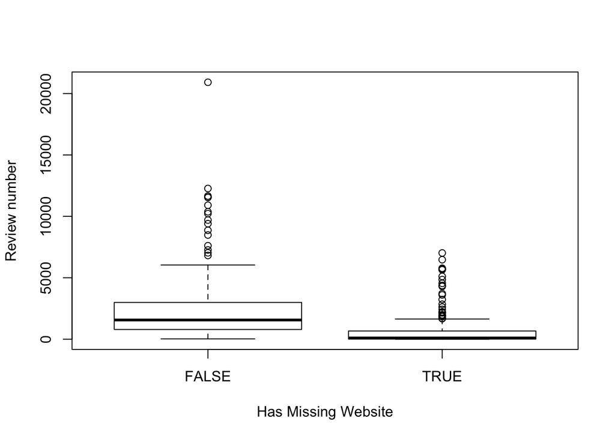

```r
reviews <- gsub(",","",daf$review_num)
daf$review_num <- as.numeric(reviews)
daf$missing_web <- is.na(daf$web)
boxplot(review_num~missing_web, data = daf, xlab = "Has Missing Website", ylab = "Review number")
```

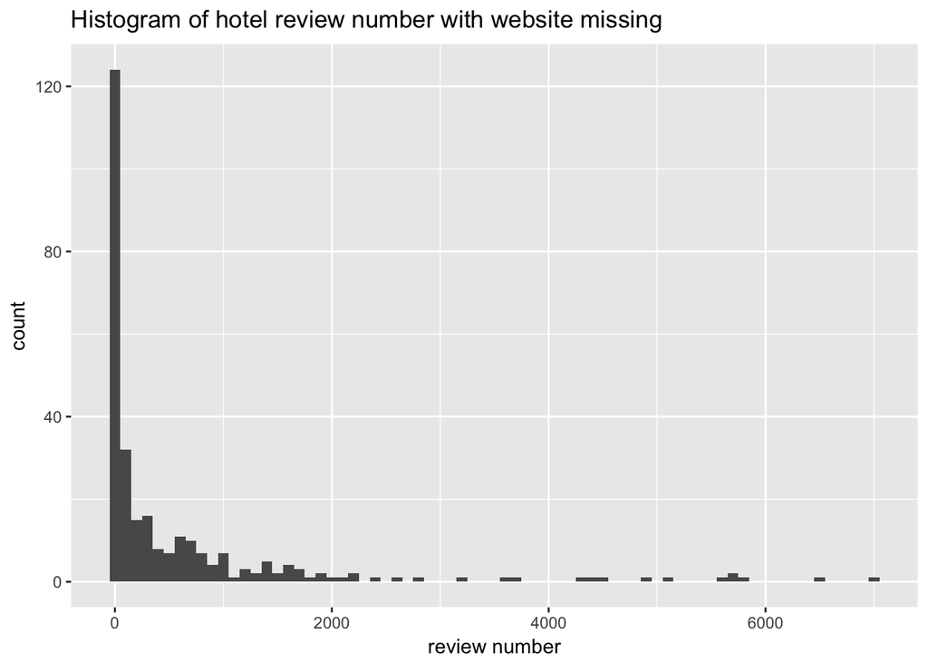

```r
ggplot(daf[!is.na(daf$one_star_rating)&is.na(daf$web),], aes(review_num)) + geom_histogram(binwidth = 100) + xlab("review number") + ggtitle("Histogram of hotel review number with website missing")
```

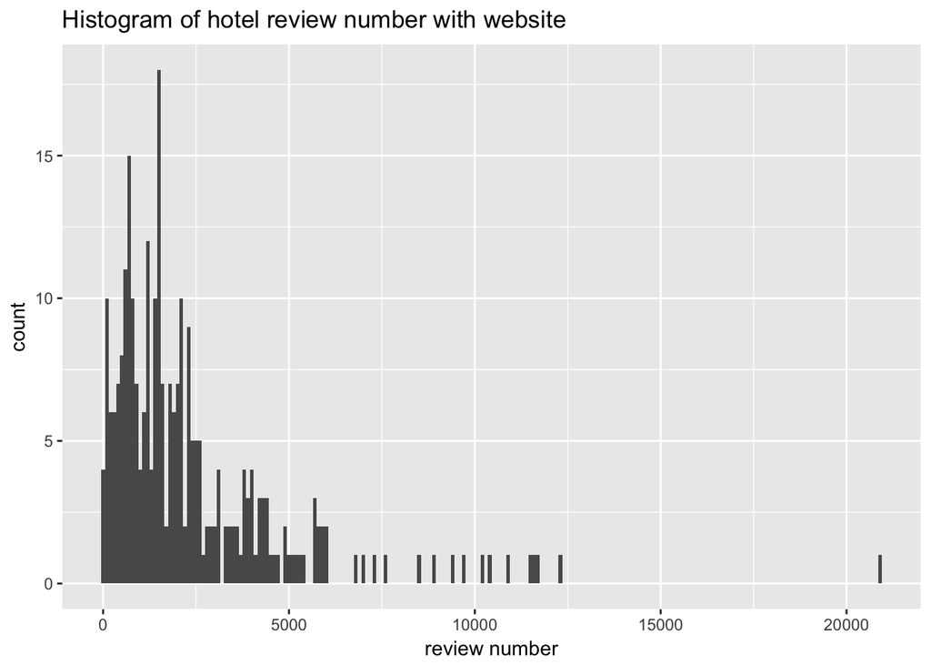

```r
ggplot(daf[!is.na(daf$one_star_rating)&!is.na(daf$web),], aes(review_num)) + geom_histogram(binwidth = 100) + xlab("review number") + ggtitle("Histogram of hotel review number with website")
```

The above two graphs show comparison of review number between hotels that have website links on TripAdvisor and those that don’t have. It is clear that for those with website missing, most of them have zero or very few reviews.

To summarize, a large proportion of hotels in NYC don’t have any missing values. For hotels with missing fields, there is no significant non-random missing patterns. We can assume that the reason of missing values is that these hotels are not very popular and so there is no detailed contact information about them on TripAdvisor. Because we have information for most popular hotels, missing data won’t have severe impact on data analysis.

## Main analysis

### Price

There are many factors that affect the prices of different hotels. Here we focuses on studying the impact of location and star on prices.

First we want to explore the relationship between price and hotel location. Our assumption is that the better the location, the higher price per night. To evaluate the locations of hotels, we need to set up a criterion. After analyzing tourists attractions, we use the distance of hotel from Time Square as the measurement of hotel location. Time Square is one of the most famous attractions here in NYC, and it is also one of the most frequent words appeared in users reviews. So the closer a hotel is to Time Square, we can say that it has a better location. We use longitude and latitude of hotels and Time Square to calculate the distance.

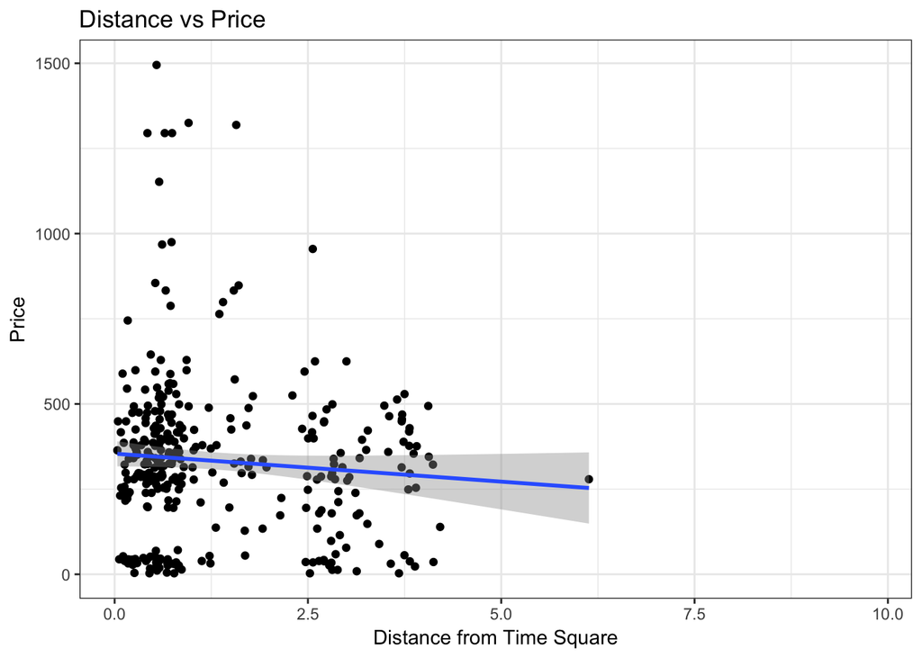

```r
prices <- gsub(",","",daf$price)
daf$price <- as.numeric(prices)
library(geosphere)
lat <- 40.7589
lgt <- -73.9851
res <- numeric(length = length(reviews))
for (i in seq_along(reviews)) {
  res[i] <- distm (c(daf$longitude[i], daf$latitude[i]), c(lgt, lat), fun = distHaversine)[,1]/1609
}
daf$distance <- res
ggplot(data = daf, aes(distance, price)) + geom_point(na.rm = T) + geom_smooth(method = lm, na.rm = T) + theme_bw() + ylab("Price") + xlab("Distance from Time Square") + ggtitle("Distance vs Price")
```

From the graph above, we can tell the following. 1. Most of the hotels are within 5 miles from Time Square, which is restricted by the size of the Manhattan Island. 2. Most of the hotels have prices lower than $600 per night. 3. Obviously there is a cluster of hotels within one mile from Time Square with prices around $400 per night. 4. For those luxury hotels with very high prices, most of them are located within one mile from Time Square. 5. The negative relationship between price and distance is not obvious, as there are also many affordable hotels near Time Square. To summarize, location doesn’t have a significant impact on prices. Some other factors, such as brand name or star may be more important issues on pricing.

The hotels in our dataset ranges from luxury 5 star to 1 star hostel, so we can visualize the distribution of price of hotels in each category.

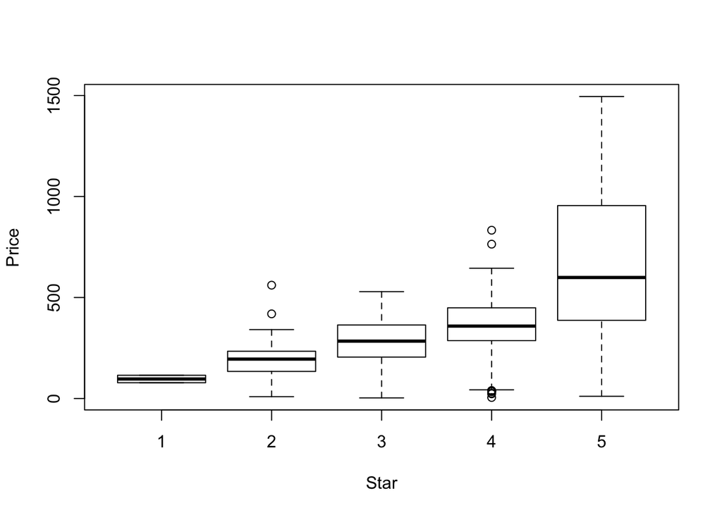

```r
boxplot(price~star, data = daf, xlab = "Star", ylab = "Price")
```

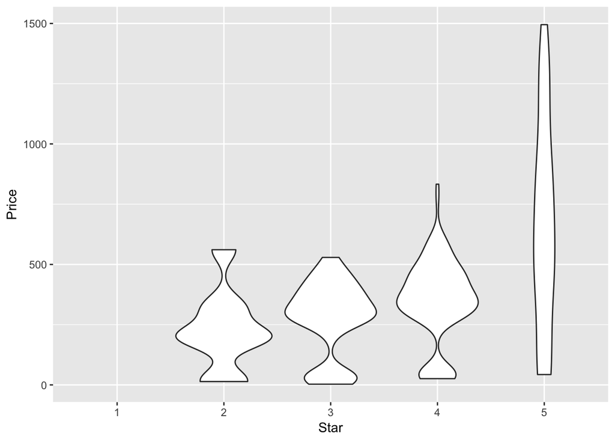

```r
ggplot(data = na.omit(daf), aes(x = as.factor(star), y = price)) + geom_violin(na.rm = T) + xlab("Star") +ylab("Price")
```

Star level has a large impact on hotel prices. We can also see that there is a significant price jump between 5 star and 4 star hotels, and the price range of 5 star hotels is much wider than hotels in other categories.

To further analyze the spatial distribution of hotels of different star levels. We plot luxury hotels(star >= 4) and economic hostels(stars <= 2) on the map.

```r
leaflet(data = daf[daf$star>=4,]) %>% addTiles() %>%
  addMarkers(~longitude, ~latitude, popup = ~as.character(name), label = ~as.character(name))
```

[interactive chart not shown]

```r
leaflet(data = daf[daf$star<=2,]) %>% addTiles() %>%
  addMarkers(~longitude, ~latitude, popup = ~as.character(name), label = ~as.character(name))
```

[interactive chart not shown]

Luxury hotels all locate at the south of Manhattan or at midtown, while economic hotels locate quite evenly on the island. And this is consistent with the economic development of Manhattan island.

### Ratings

For each hotel, there is a general ratings, which is the average of all users ratings of the hotel. Ratings range from 0 to 5, with 0 representing the worst and 5 representing the best.

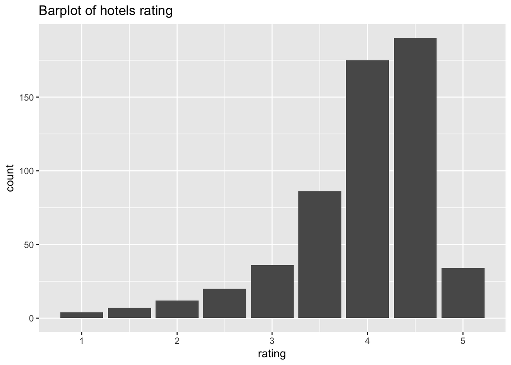

```r
ggplot(data = daf, aes(rating)) + geom_bar(na.rm = T) + ggtitle("Barplot of hotels rating")
```

We can see that most travellers are satisfied with the hotels in NYC. Most hotels have ratings between 3.5 and 4.5.

Next we explore the relationship between ratings and price. Do 5 star hotels really worth the price?

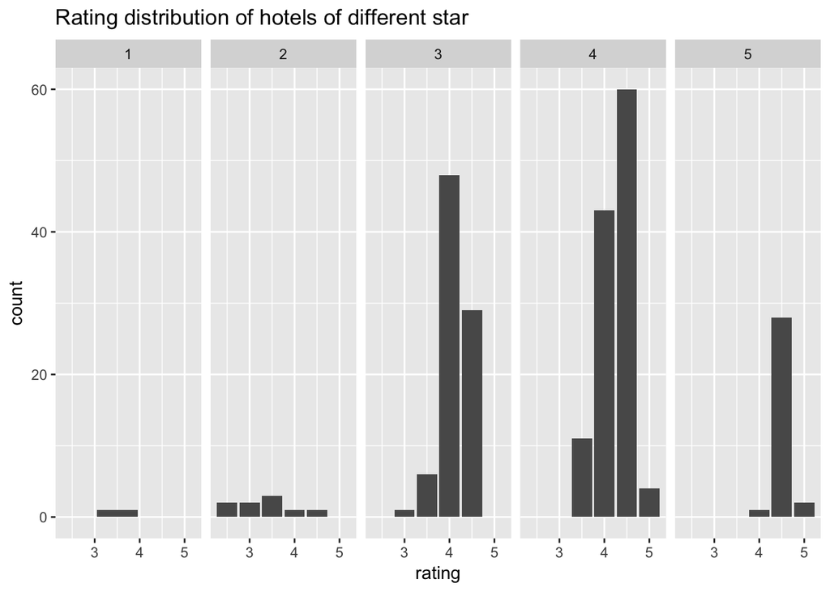

```r
ggplot(data = na.omit(daf), aes(rating)) + geom_bar(na.rm = T) + facet_grid(.~star) + ggtitle("Rating distribution of hotels of different star")
```

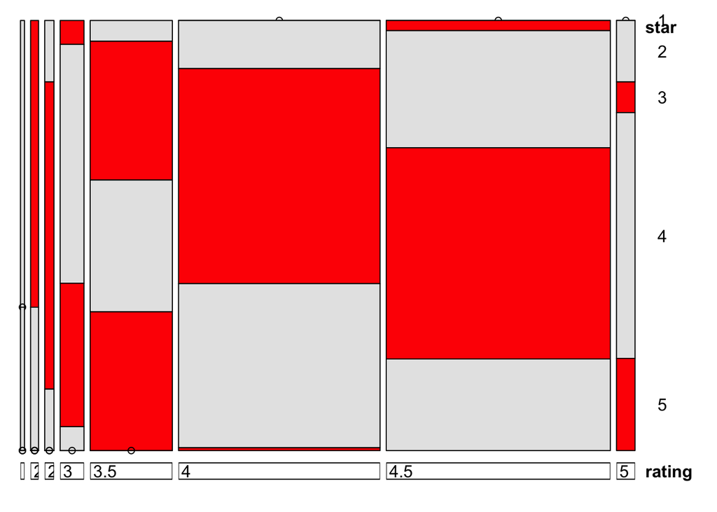

```r
doubledecker(star~rating, data = daf ,gp = gpar(fill = c("grey90", "red")))
```

Generally speaking, luxury hotels are much more satisfactory than affordable ones. All 5 start hotels have ratings 3.5 or above, while all 4 star hotels have rating 3 or above.

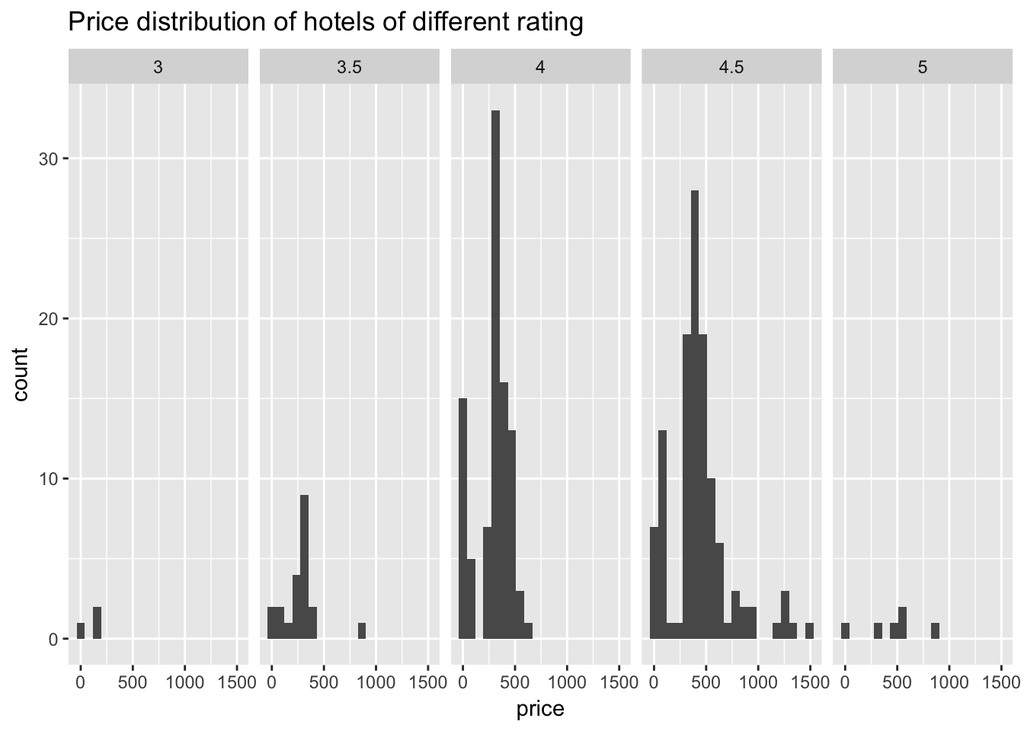

```r
ggplot(data = na.omit(daf[daf$rating>=3,]), aes(price)) + geom_histogram(na.rm = T, bins = 20) + facet_grid(.~rating) + ggtitle("Price distribution of hotels of different rating")
```

To further explore the relationship between price and rating, we group hotels by rating and plot the price distribution for rating from 3 to 5(hotels with rating below 3 are few so we ignore them). Here are some findings of above plots: 1. The higher the rating, the higher average price of hotels(the center bar shifts right). 2. 4 and 4.5 are most common ratings, and most hotels of these ratings are clustered around the highest bar, with a few hotels with very high prices. 3. Hotels with highest price have rating 4.5 more than rating 5, which makes sense because people have higher expectation for super expensive hotels. 4. Only one hotel with price over 750 has a rating under 4.5, which implies the price is relatively “fair” for the quality of hotels.

### Review Numbers

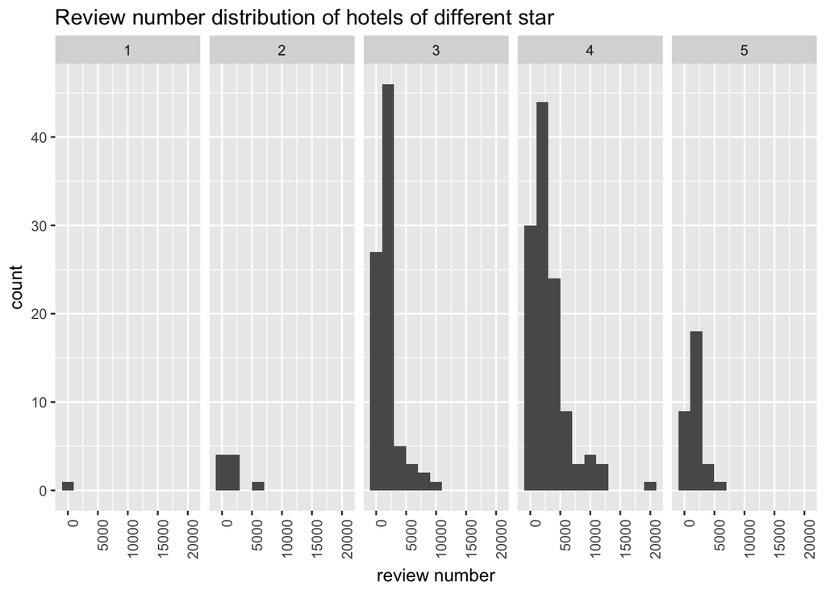

```r
ggplot(data = na.omit(daf), aes(review_num)) + geom_histogram(na.rm = T, binwidth = 2000) + facet_grid(.~star) + theme(axis.text.x = element_text(angle = 90, hjust = 1)) + xlab("review number")  + ggtitle("Review number distribution of hotels of different star")
```

Here we plot the distribution of review numbers for different star level to analyse the popularity of hotels. What we can conclude from the plots are: 1. For hotels with star 3 or less, most of them have very few reviews(less than 2500). A small proportion of 3-star hotels have more than 5000 reviews. 2. 4-star hotels have the most number of reviews on average. About 1/3 of them have more than 2500 reviews, which indicates people like to choose 4-star hotels to balence the quality and price. 3. 5-star hotels doesn’t have much review numbers compair with 3-star and 4-star hotels. It might be the case that they are too expensive to attract lots of customers.

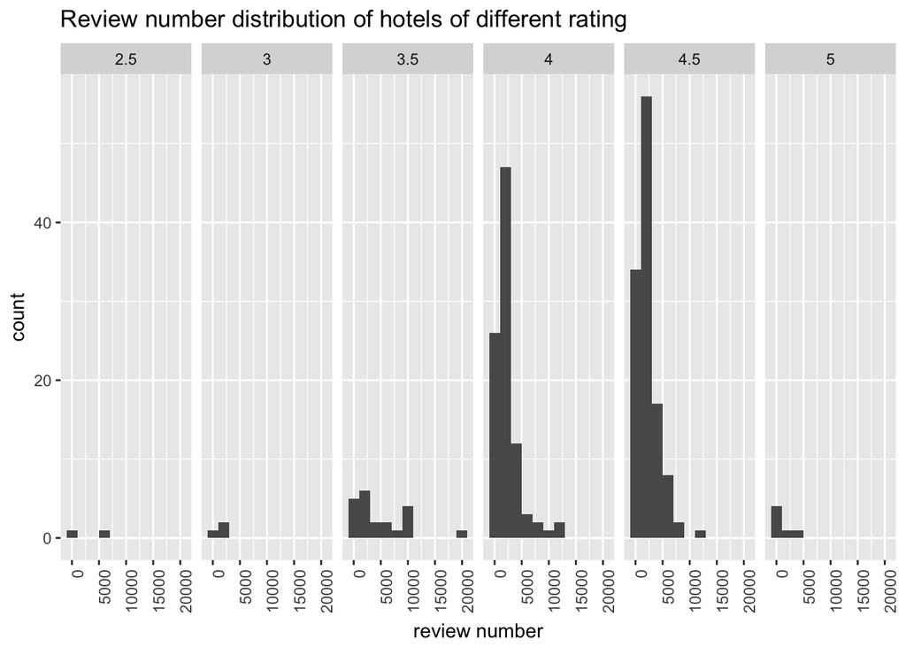

```r
ggplot(data = na.omit(daf), aes(review_num)) + geom_histogram(na.rm = T, binwidth = 2000) + facet_grid(.~rating) + theme(axis.text.x = element_text(angle = 90, hjust = 1)) + xlab("review number")  + ggtitle("Review number distribution of hotels of different rating")
```

We plots the distribution of review numbers over each rating level from 2.5 to 5. Here we have similar findings as the previous discussion: 1. Hotels with more than 5000 reviews are generally have 4 or 4.5 ratings. One the one hand, 4 and 4.5 are the most common ratings for hotels in New York; On the other hand, hotels with 4 or 4.5 ratings are most likely to attact customers. 2. Hotels with rating 5 doesn’t have much reviews(all less than 5000)! On the one hand, our sample is small so it might be bias; on the other hands, maybe people don’t give feedback if they are satisfy with everything(only give a five star rating).  
3. It’s a little suprising that the proportion of hotels with 3.5 rating but more than 5000 reviews is not small(even with one hotel over 20000 reviews). We pick some of hotels and look at their address, finding that they have very good locations so they can attract lots of customers. This inspire us to analysis the relationship between location and review numbers in the next plot.

```r
leaflet(data = daf[daf$review_num>=2000,]) %>% addTiles() %>%
  addMarkers(~longitude, ~latitude, popup = ~as.character(name), label = ~as.character(name))
```

[interactive chart not shown]

```r
leaflet(data = daf[daf$review_num>=3000,]) %>% addTiles() %>%
  addMarkers(~longitude, ~latitude, popup = ~as.character(name), label = ~as.character(name))
```

[interactive chart not shown]

```r
leaflet(data = daf[daf$review_num>=5000,]) %>% addTiles() %>%
  addMarkers(~longitude, ~latitude, popup = ~as.character(name), label = ~as.character(name))
```

[interactive chart not shown]

As we can conclude from the above plots, there is obvious centralized pattern as the number of reviews increases. Hotels with over 2000 reviews are located around Time Squares, Downtown and West side of central park, but all hotels over 5000 reviews are around Time square. Therefore, geolocation has a great effect on the popularity of hotels in Manhatten.

### Facilities

```r
library(gridExtra)
```

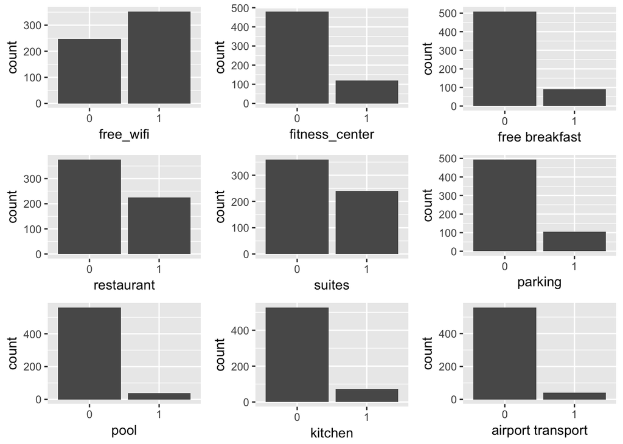

```r
p1 <- ggplot(data = daf, aes(as.factor(free_wifi))) + geom_bar() + xlab("free_wifi")
p2 <- ggplot(data = daf, aes(as.factor(fitness_center))) + geom_bar() + xlab("fitness_center")
p3 <- ggplot(data = daf, aes(as.factor(breakfast_included))) + geom_bar() + xlab("free breakfast")
p4 <- ggplot(data = daf, aes(as.factor(restaurant))) + geom_bar() + xlab("restaurant")
p5 <- ggplot(data = daf, aes(as.factor(suites))) + geom_bar() + xlab("suites")
p6 <- ggplot(data = daf, aes(as.factor(parking))) + geom_bar() + xlab("parking")
p7 <- ggplot(data = daf, aes(as.factor(pool))) + geom_bar() + xlab("pool")
p8 <- ggplot(data = daf, aes(as.factor(kitchenette))) + geom_bar() + xlab("kitchen")
p9 <- ggplot(data = daf, aes(as.factor(airport_transportation))) + geom_bar() + xlab("airport transport")
grid.arrange(p1, p2, p3, p4, p5, p6, p7, p8, p9, nrow = 3)
```

Here we want to find some popular facilities for hotels in NYC, and we pick 9 of 43 binary variables based our interests. Free wifi, restaurant and suites are the most common facilities provided by hotels in NYC, but very few hotels provides pool, kitchen, parking and free breakfast. As we can imagin, NYC(expecially manhatten) has limited space and everything is expensive.

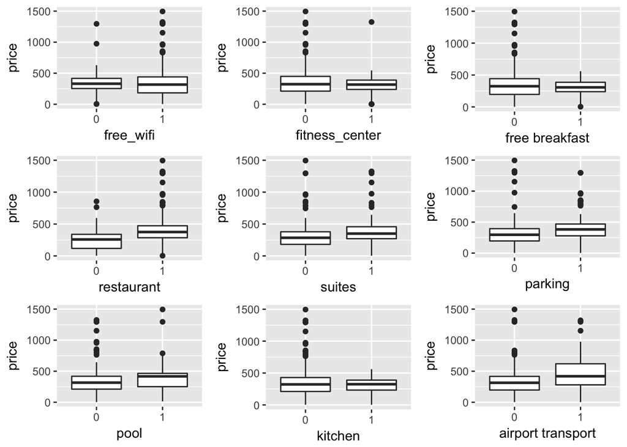

```r
p1 <- ggplot(data = daf, aes(as.factor(free_wifi), price)) + geom_boxplot(na.rm = T) + xlab("free_wifi")
p2 <- ggplot(data = daf, aes(as.factor(fitness_center), price)) + geom_boxplot(na.rm = T) + xlab("fitness_center")
p3 <- ggplot(data = daf, aes(as.factor(breakfast_included), price)) + geom_boxplot(na.rm = T) + xlab("free breakfast")
p4 <- ggplot(data = daf, aes(as.factor(restaurant), price)) + geom_boxplot(na.rm = T) + xlab("restaurant")
p5 <- ggplot(data = daf, aes(as.factor(suites), price)) + geom_boxplot(na.rm = T) + xlab("suites")
p6 <- ggplot(data = daf, aes(as.factor(parking), price)) + geom_boxplot(na.rm = T) + xlab("parking")
p7 <- ggplot(data = daf, aes(as.factor(pool), price)) + geom_boxplot(na.rm = T) + xlab("pool")
p8 <- ggplot(data = daf, aes(as.factor(kitchenette), price)) + geom_boxplot(na.rm = T) + xlab("kitchen")
p9 <- ggplot(data = daf, aes(as.factor(airport_transportation), price)) + geom_boxplot(na.rm = T) + xlab("airport transport")
grid.arrange(p1, p2, p3, p4, p5, p6, p7, p8, p9, nrow = 3)
```

Here we want to find out whether hotels with more facilities are more expensive in general, so we draw box plot so see if there is a price difference over the same 9 binary variables as the previous section. Notice that hotels with parking, suites, restaurants, pool and airport transportations are more expensive than hotels without those facilities. However, there are some counter-intuitive facts. Hotels with fitness center and free breakfast are less expensive than hotels without. While this findings seem to be non-sensical, it may be due to some other factors which we will explore later. Hotels with kitchen are less expensive than those without, this makes sense because hotels with kitchen tend to be resorts and locates far away from city center with lower star level.

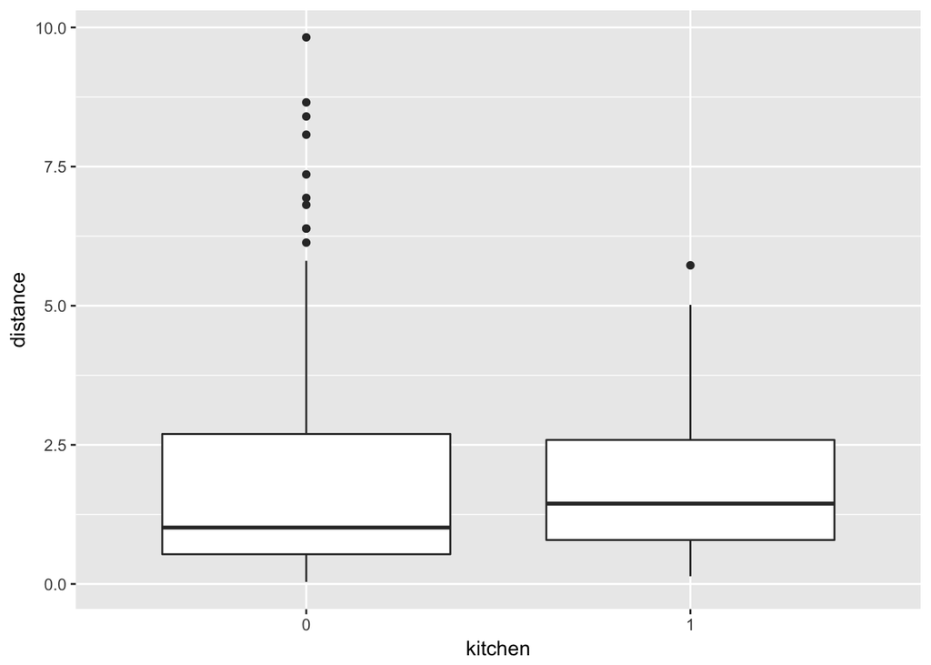

```r
ggplot(data = daf, aes(as.factor(kitchenette), distance)) + geom_boxplot(na.rm = T) + xlab("kitchen")
```

```r
mean(daf[daf$kitchenette==1,]$distance)
```

```
## [1] 1.822861
```

```r
mean(daf[daf$kitchenette==0,]$distance)
```

```
## [1] 1.673229
```

```r
mean(daf[daf$kitchenette==0,]$star, na.rm = T)
```

```
## [1] 3.422392
```

```r
mean(daf[daf$kitchenette==1,]$star, na.rm = T)
```

```
## [1] 3
```

The graph and statistics above support our assumption that hotels with kitchen tend to locate far away from city center with lower star level.

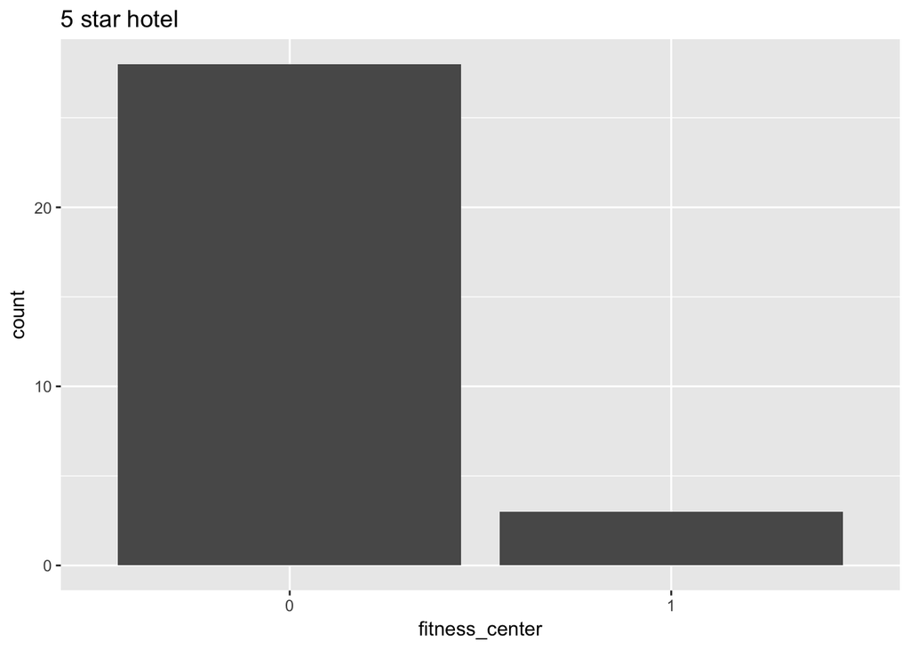

```r
ggplot(data = na.omit(daf[daf$star==5,]), aes(as.factor(fitness_center))) + geom_bar(na.rm = T) + xlab("fitness_center") + ggtitle("5 star hotel")
```

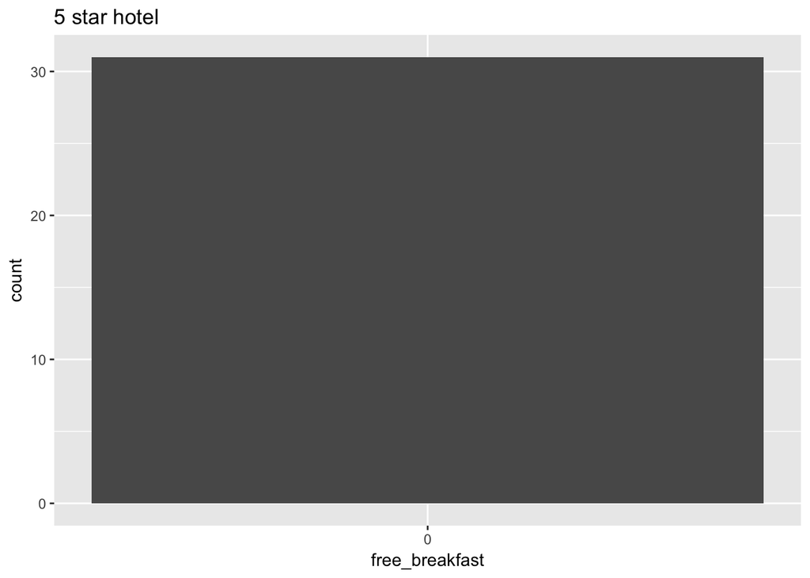

```r
ggplot(data = na.omit(daf[daf$star==5,]), aes(as.factor(breakfast_included))) + geom_bar(na.rm = T) + xlab("free_breakfast") + ggtitle("5 star hotel")
```

The graph above shows that most 5-star hotels don’t have free breakfast or fitness center. This explains the findings that hotels with fitness center and free breakfast are less expensive than hotels without. When further analyzing the TripAdvisor website, we found out that for each hotel, the space is limited for it to present its facilities, which means that if a hotel has all kinds of facilities, it has to choose some of them to highlight. So for 5 star hotels, most of them won’t showcase that they have fitness center. As a result, when we got our data, if we didn’t find a fitness center sign, we had to just assume that it didn’t have one. This is the reason of this bias.

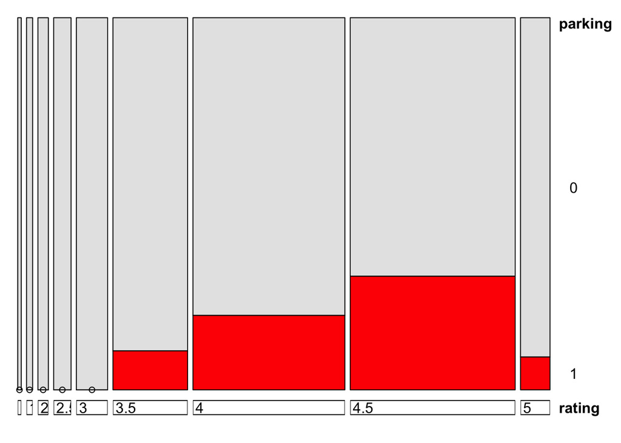

```r
doubledecker(parking~rating, data = daf ,gp = gpar(fill = c("grey90", "red")))
```

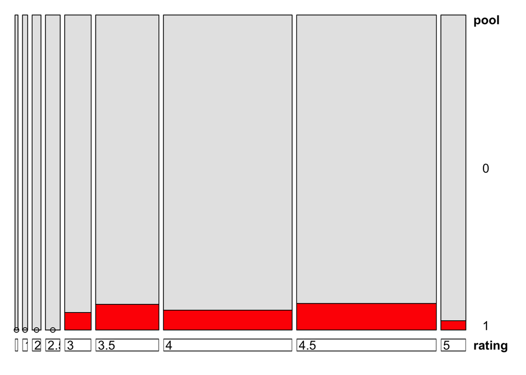

```r
doubledecker(pool~rating, data = daf ,gp = gpar(fill = c("grey90", "red")))
```

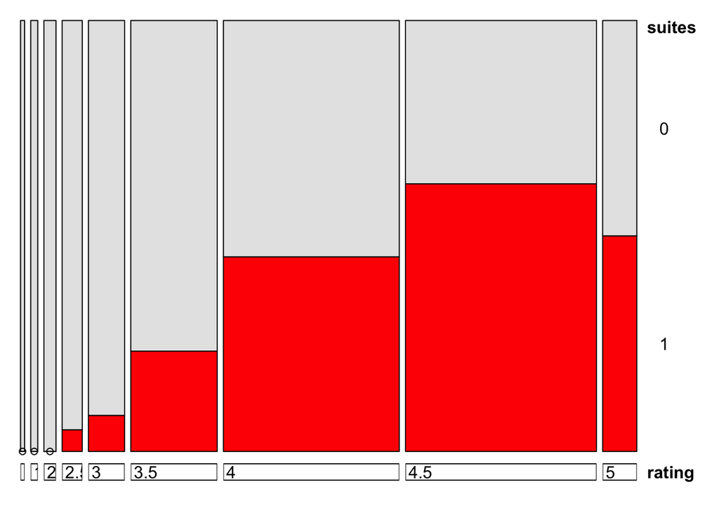

```r
doubledecker(suites~rating, data = daf ,gp = gpar(fill = c("grey90", "red")))
```

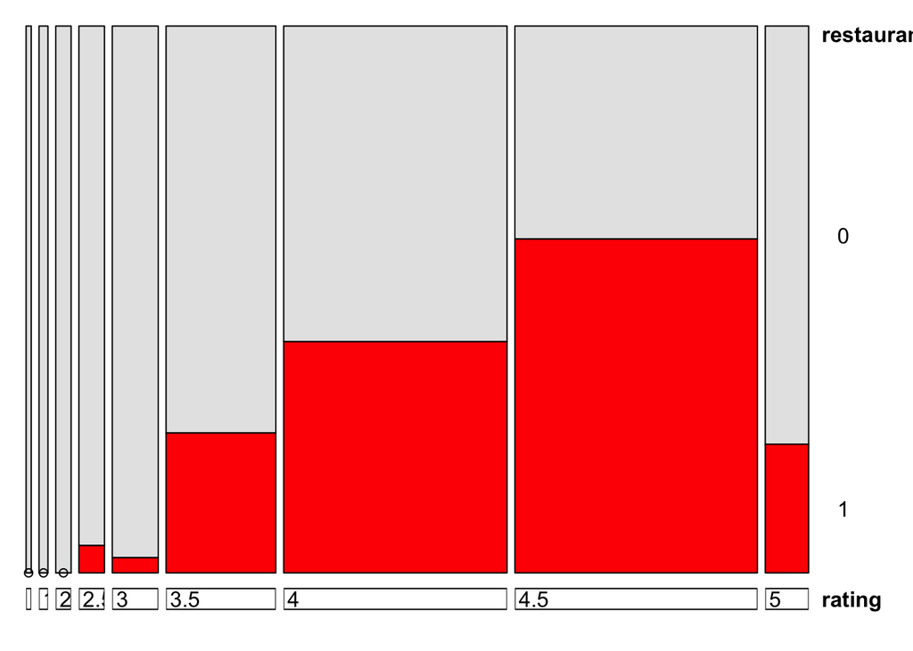

```r
doubledecker(restaurant~rating, data = daf ,gp = gpar(fill = c("grey90", "red")))
```

Then we want to explore the relationship between rating and “luxury features”, and our assumption is hotels with such facility should have higher rating than those without those features. We select “pool”, “suites” and “restaurants” to do analysis because hotels with these facilities are more expensive in general(more “luxurious”). We find out that such features do have positive correlation with ratings. Although hotels with pool are almost uniformly distributed from rating 3 to 5, there are increasing number of hotels with suites and restaurants from rating 2.5 to 4.5.One interesting finding here is for hotels with rating 5, there is a negative effect of having those “luxury” features(pool, suite and restaurant), which is pretty counter-intuitive. We guess the reason might be hotels with these features have super high price, so not every person want to give a 5-star rating to such hotels, therefore 4.5 ratings are most common. However, hotels with lower price but more “useful” facilities such as free wifi and free breakfast tend to receive 5-star ratings because these features really meet people’s requirements.

## Executive Summary

1. Geolocation has great effect on price and average number of rating(centralized to Time Square)

```r
leaflet(data = daf[daf$price>=200 & daf$price<400,]) %>% addTiles() %>%
  addMarkers(~longitude, ~latitude, popup = ~as.character(name), label = ~as.character(name))
```

[interactive chart not shown]

```r
leaflet(data = daf[daf$price>=400 & daf$price<800,]) %>% addTiles() %>%
  addMarkers(~longitude, ~latitude, popup = ~as.character(name), label = ~as.character(name))
```

[interactive chart not shown]

```r
leaflet(data = daf[daf$price>=800,]) %>% addTiles() %>%
  addMarkers(~longitude, ~latitude, popup = ~as.character(name), label = ~as.character(name))
```

[interactive chart not shown]

The above 3 plots show how hotels with price within $200 - $400, $400 - $800 and over 800 distribute on map. In general there are two clusters, one between 23 street and 59 street and another at very south area. The most expensive(over $800) hotels locate in east mid-town area and they clustered together. Also, no hotels over $400 locate above 72 street. These observations conclude that geolocation have high impact on hotel price.

```r
leaflet(data = daf[daf$review_num>=3000,]) %>% addTiles() %>%
  addMarkers(~longitude, ~latitude, popup = ~as.character(name), label = ~as.character(name))
```

[interactive chart not shown]

```r
leaflet(data = daf[daf$review_num>=5000,]) %>% addTiles() %>%
  addMarkers(~longitude, ~latitude, popup = ~as.character(name), label = ~as.character(name))
```

[interactive chart not shown]

```r
leaflet(data = daf[daf$review_num>=7000,]) %>% addTiles() %>%
  addMarkers(~longitude, ~latitude, popup = ~as.character(name), label = ~as.character(name))
```

[interactive chart not shown]

```r
leaflet(data = daf[daf$review_num>=9000,]) %>% addTiles() %>%
  addMarkers(~longitude, ~latitude, popup = ~as.character(name), label = ~as.character(name))
```

[interactive chart not shown]

Similar impact also exists between geolocation and review numbers. As the review number increases, hotels are more like to appear between 42 street and 59 street.

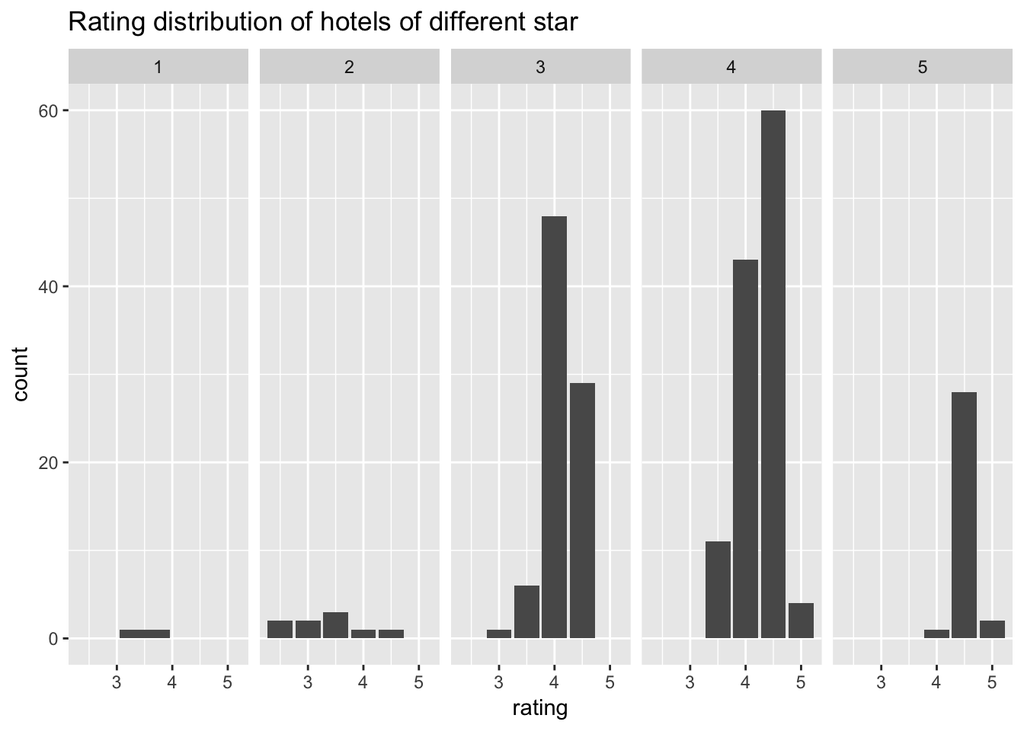

```r
ggplot(data = na.omit(daf), aes(rating)) + geom_bar(na.rm = T) + facet_grid(.~star) + ggtitle("Rating distribution of hotels of different star")
```

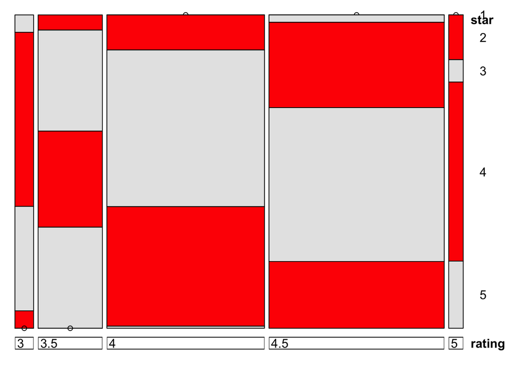

```r
doubledecker(star~rating, data = daf[daf$rating>=3,] ,gp = gpar(fill = c("grey90", "red")))
```

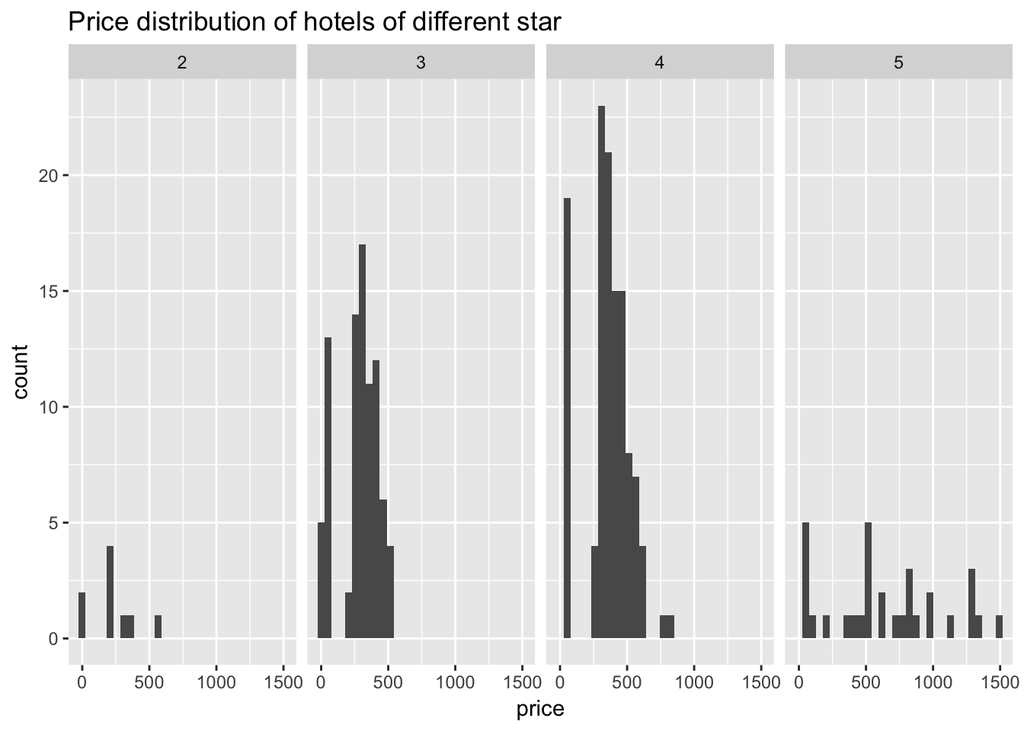

```r
ggplot(data = na.omit(daf[daf$star>1,]), aes(price)) + geom_histogram(na.rm = T) + facet_grid(.~star) + ggtitle("Price distribution of hotels of different star")
```

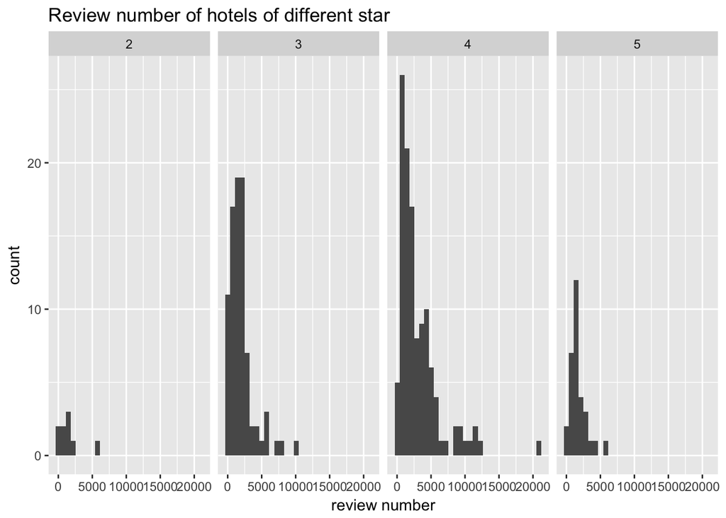

```r
ggplot(data = na.omit(daf[daf$star>1,]), aes(review_num)) + geom_histogram(na.rm = T) + facet_grid(.~star) + ggtitle("Review number of hotels of different star") + xlab("review number")
```

3. “More facilities” is not equal to “better hotels”. What type of facilities matter here.

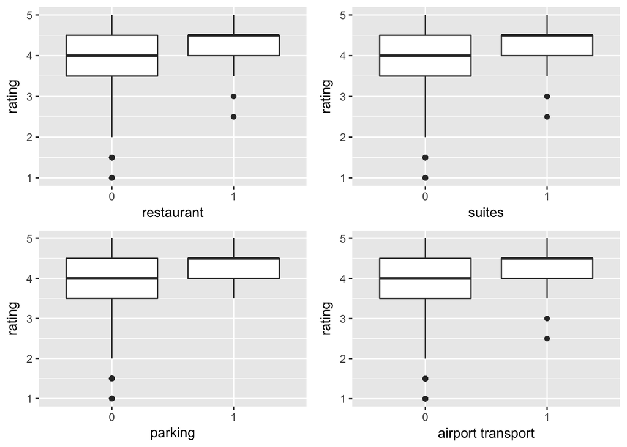

```r
p4 <- ggplot(data = daf, aes(as.factor(restaurant), rating)) + geom_boxplot(na.rm = T) + xlab("restaurant")
p5 <- ggplot(data = daf, aes(as.factor(suites), rating)) + geom_boxplot(na.rm = T) + xlab("suites")
p6 <- ggplot(data = daf, aes(as.factor(parking), rating)) + geom_boxplot(na.rm = T) + xlab("parking")
p9 <- ggplot(data = daf, aes(as.factor(airport_transportation), rating)) + geom_boxplot(na.rm = T) + xlab("airport transport")
grid.arrange(p4, p5, p6, p9, nrow = 2)
```

“Luxury features” such as restaurant and suites will lead to better average rating because these features indicates these hotels are “luxurious”. Also, “useful features” like parking and airport transpotation meet people requirement so people tend give higher rating to them.

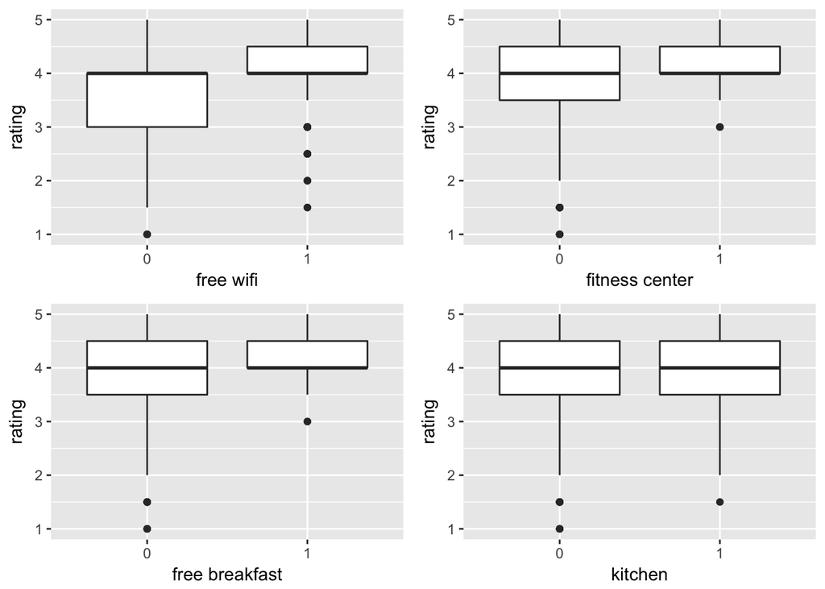

```r
p1 <- ggplot(data = daf, aes(as.factor(free_wifi), rating)) + geom_boxplot(na.rm = T) + xlab("free wifi")
p2 <- ggplot(data = daf, aes(as.factor(fitness_center), rating)) + geom_boxplot(na.rm = T) + xlab("fitness center")
p3 <- ggplot(data = daf, aes(as.factor(breakfast_included), rating)) + geom_boxplot(na.rm = T) + xlab("free breakfast")
p8 <- ggplot(data = daf, aes(as.factor(kitchenette), rating)) + geom_boxplot(na.rm = T) + xlab("kitchen")
grid.arrange(p1, p2, p3, p8, nrow = 2)
```

## Interaction Part

Website URL: https://nychotelfinder.herokuapp.com

Documentation URL: https://nychotelfinder.herokuapp.com/about_us

Source code: https://github/com/suils789/STAT5702---EDAV

## Conclusion

What we have achieved:

1. Search hotels by address, filter by price, stars and facilities, then show results on a map.
2. Show users rating distribution of each individual hotels, represented by bar charts.
3. Show users the 10 nearest hotels and its own price to do comparsion, represented by Cleveland got plots.
4. Provide a comprehensive analysis of the relationship between price, average ratings, star-level and geolocation.

Future Work:

1. Scrape more data, probably more hotels in other borough(Queens, Brookline, Bronx…)
2. Add “search by division” function: Make it available to search by area(Upper east, Downtown…)
3. Allow users to view price and rating distribution over a region, rather than only show them 10 hotels nearby. 4.Making recommendations besed on ratings and prices

Limitations of our project:

1. We scrap hotels’ data from TripAdvisor, which only provides limited number of tags. For example, large, luxury hotels are usually tagged by fancier tags such as “Suites”, “Pool”, “Rooftop bar”, while small hotels usually tagged with “breakfast”, “kousekeeping” these kind of tags. But it doesn’t mean than luxury hotels don’t provide breakfast and house keeping. This fact may cause bias in our analysis.
2. There are other factors that affect price and rating that we didn’t capture, such as brand and seasonality.
3. Our price data come from one specific night, but the price of hotels could fluctuate in a wide range.

Lessons Learned:

1. Using python packages to do web scripcing
2. Data cleaning, find patterns about missing values(MAR or NMAR)
3. Choose proper type of graph representation to plot different kinds of data(discrete and continuous data in different dimension), and make inferences from them.
4. How to build foundend with HTML and different style sheets, and making it dynamic using Javascript, D3 and GoogleMap API.
5. Cooperate the frondend into a web app frame work(Django for this project), then deploy it online.